# BuildLogisticRegressionModel

Rolando

3/2/2020

## Final Data

- 共有三份Data，分別為 **FinalData_IPO, FinalData_FS, FinalData_ROTCTrading**
- 更改過的變數如下：
1. 平均中籤率 : 原本根據 **申購積極性對新上市公司股票績效的影響 (王朝仕、陳振遠 2008，管理學報)**，是利用 log (1/中籤率) 作為積極性的代理變數，但由於data中的資料有公司的中籤率為0，無法使用此方式計算， 因此直接以平均中籤率作為積極性的代理變數。
2. LogMarketValueOnIPODay : 將 Market Value 取 log。
3. HoldingDecreaseToUnderWrittenShares(%) : 改以承銷量作為分母計算。
4. Dividend_Dummy、NegativeNetIncome : 新增此兩變數代表是否發放股利或是否有負的NI (IPO前最後一季財報。)
5. SD_Return250DaysAfterIPO : 計算IPO後250個交易日之報酬率標準差。
6. SD_MarketModelResidual : 計算IPO後250個交易日之四因子模型殘差，代表公司的獨有風險。

```r
load("Data/FinalData_IPO.RData")
load("Data/FinalData_FS.RData")
load("Data/FinalData_ROTCTrading.RData")

FinalData_Basic <- FinalData_FS %>%
  .[, .SD, .SDcols = c(1:8)]

FinalData_FS <- FinalData_FS %>%
  .[, .SD, .SDcols = -c(2:8)]

JoinList <- list(FinalData_FS, FinalData_IPO, FinalData_ROTCTrading)

FinalDataWithAllVariable <- plyr::join_all(JoinList, by = "公司簡稱", type = 'left', match = "all") %>%
  setDT() %>%
  dplyr::select(., "公司簡稱", "IPOFail", everything())

# 顯示出 FinalData_IPO 所有結果，並以滾動捲軸呈現
FinalData_IPO %>%
  dplyr::select(everything()) %>%
  kable("html", escape = F, align = "l") %>%
  kable_styling("hover", full_width = T) %>%
  scroll_box(width = "800px", height = "500px")
```

| 公司簡稱 | IPOFail | Market | 承銷價格(元) | FirstDayReturn(%) | 平均中籤率 | 總承銷股數(千股) | 承銷金額(千元) | ROTC_Time | ElectricOrNot | FirmAgeBeforeIPO | UnderWritingPercentage | Market_CR | OtherIPOFirstDayReturn | OtherIPOInitialReturn | IPOHeatDegree | LogMarketValueOnIPODay | Big4Natl | NumIPOSign | EWUSign | HoldingDiff | HoldingDecreaseToUnderWrittenShares(%) | 員工認購率 % | 機構持股(比率) | 獨立董事人數 |
| --- | --- | --- | --- | --- | --- | --- | --- | --- | --- | --- | --- | --- | --- | --- | --- | --- | --- | --- | --- | --- | --- | --- | --- | --- |
| 1259 安心 | 0 | 0 | 166.00 | -0.6024096 | 4.49 | 4862 | 807092.0 | 0.8849315 | 0 | 21.074 | 15.8420872 | -0.301 | 0.1309389 | 0.1072749 | 69 | 22.30389 | 1 | 3 | 1 | 1857.00000 | 9.0909091 | 15.00 | 73.58000 | 3 |
| 1333 恩得利 | 0 | 0 | 32.00 | 0.0000000 | 1.23 | 5074 | 162368.0 | 1.5315068 | 1 | 11.819 | 11.7702623 | -0.099 | 0.0689312 | 0.2675835 | 80 | 21.27023 | 0 | 2 | 3 | -2782.00000 | 55.9716200 | 0.00 | 42.04000 | 2 |
| 1336 台翰 | 0 | 0 | 52.00 | 26.5384615 | 3.42 | 6450 | 335400.0 | 1.8876712 | 1 | 20.195 | 11.7702623 | 0.238 | 0.5294978 | 0.5370588 | 29 | 22.11951 | 1 | 3 | 1 | -256.00000 | 4.8062016 | 14.99 | 35.01000 | 2 |
| 1338 廣華-KY | 0 | 1 | 80.00 | -3.7500000 | 10.57 | 7100 | 568000.0 | 2.1863014 | 0 | 3.033 | 4.3674298 | -0.129 | 0.1543228 | 0.1690494 | 70 | 22.42200 | 1 | 3 | 2 | 51.00000 | 0.0000000 | 11.25 | 41.45000 | 3 |
| 1339 昭輝 | 0 | 1 | 29.50 | 0.0000000 | 6.33 | 5856 | 172752.0 | 1.0356164 | 0 | 26.151 | 1.3203927 | -0.097 | 0.4651432 | 0.4132025 | 75 | 21.38853 | 1 | 2 | 2 | -488.00000 | 8.8456284 | 10.00 | 51.89000 | 3 |
| 1558 伸興 | 0 | 0 | 25.00 | 22.0000000 | 6.10 | 4772 | 119300.0 | 3.6657534 | 0 | 33.005 | 11.7702623 | 0.118 | 0.1938183 | 0.1305193 | 29 | 20.98717 | 1 | 3 | 1 | 236.00000 | 0.8801341 | 15.00 | 25.05000 | 2 |
| 1560 中砂 | 0 | 1 | 60.00 | 6.6666667 | 24.91 | 6260 | 375600.0 | 0.7972603 | 0 | 40.595 | 3.8478474 | 0.066 | 0.0068976 | -0.0067316 | 98 | 22.18791 | 1 | 2 | 3 | -1302.00000 | 20.7987220 | 0.00 | 32.28000 | 2 |
| 1565 精華 | 0 | 0 | 46.00 | 6.9565217 | 1.45 | 2967 | 136482.0 | 0.6739726 | 0 | 17.526 | 3.8478474 | 0.554 | 0.0226281 | 0.0968190 | 101 | 21.18385 | 1 | 3 | 3 | -1362.00000 | 45.9049545 | 0.00 | 29.23000 | 2 |
| 1566 捷邦 | 0 | 0 | 19.00 | 51.5789474 | 1.41 | 4142 | 78698.0 | 6.8273973 | 0 | 34.115 | 2.5646976 | 0.227 | 0.2174776 | 0.1980974 | 46 | 20.75960 | 1 | 3 | 2 | -400.00000 | 13.8097537 | 14.99 | 62.21000 | 4 |
| 1568 倉佑 | 0 | 1 | 22.60 | 24.7787611 | 3.78 | 10609 | 239763.4 | 9.9013699 | 0 | 29.342 | 2.3460259 | 0.236 | 0.4936910 | 0.3387382 | 65 | 21.79039 | 1 | 1 | 2 | -240.00000 | 2.9220473 | 10.00 | 59.74000 | 3 |
| 1569 濱川 | 0 | 0 | 28.00 | 6.9642857 | 0.90 | 2970 | 83160.0 | 1.1698630 | 1 | 22.348 | 11.7480555 | -0.045 | 0.0610944 | 0.2101349 | 80 | 20.93838 | 1 | 2 | 3 | -2183.00000 | 82.0875421 | 10.00 | 31.51000 | 2 |
| 1570 力肯 | 0 | 0 | 53.00 | 1.8867925 | 2.87 | 2734 | 144902.0 | 1.0164384 | 0 | 21.534 | 4.9614154 | 0.002 | 0.0229898 | 0.0981433 | 81 | 21.21000 | 1 | 2 | 3 | 425.00000 | 2.5603511 | 0.00 | 24.94000 | 2 |
| 1580 新麥 | 0 | 0 | 33.00 | 9.3939394 | 7.02 | 3572 | 117876.0 | 1.0712329 | 0 | 24.219 | 4.3126573 | 0.323 | 0.1938183 | 0.1305193 | 29 | 20.96228 | 1 | 3 | 1 | 1015.00000 | 0.0000000 | 15.00 | 23.29000 | 2 |
| 1582 信錦 | 0 | 0 | 128.00 | 44.5312500 | 1.18 | 4095 | 524160.0 | 1.0520548 | 1 | 27.534 | 11.7480555 | 0.281 | 1.5454545 | 1.4454545 | 46 | 22.59121 | 1 | 1 | 2 | 961.00000 | 0.9035409 | 14.99 | 9.88000 | 2 |
| 1583 程泰 | 0 | 1 | 60.00 | -0.1666667 | 100.00 | 8216 | 492960.0 | 1.0767123 | 0 | 32.345 | 11.7480555 | 0.155 | 0.0977919 | 0.0923822 | 54 | 22.34424 | 0 | 2 | 1 | 2471.00000 | 2.9454722 | 15.00 | 43.05000 | 3 |
| 1584 精剛 | 0 | 0 | 43.00 | 1.1627907 | 3.11 | 4453 | 191479.0 | 0.9561644 | 0 | 5.542 | 9.3643455 | 0.200 | 0.5294978 | 0.5370588 | 29 | 21.27715 | 1 | 3 | 1 | -357.00000 | 8.9827083 | 15.00 | 70.85000 | 3 |
| 1586 和勤 | 0 | 0 | 18.50 | 2.7027027 | 10.13 | 4921 | 91038.5 | 2.1178082 | 0 | 19.178 | 2.5646976 | -0.320 | -0.0059353 | -0.0554816 | 83 | 20.60223 | 1 | 2 | 3 | 120.00000 | 5.0802682 | 10.00 | 46.66000 | 2 |
| 1591 駿吉-KY | 0 | 0 | 28.00 | 45.3571429 | 0.96 | 1769 | 49532.0 | 1.9561644 | 0 | 2.342 | 2.5646976 | -0.179 | 0.4097416 | 0.4105699 | 83 | 20.53452 | 1 | 2 | 3 | 35.00000 | 0.0000000 | 10.00 | 61.12000 | 3 |
| 1593 祺驊 | 0 | 0 | 27.00 | 15.1851852 | 3.27 | 2052 | 55404.0 | 1.7616438 | 0 | 15.258 | 11.7480555 | -0.298 | 0.3071726 | 0.2632207 | 75 | 20.45539 | 1 | 2 | 2 | -140.00000 | 9.1617934 | 15.00 | 13.08000 | 3 |
| 1595 川寶 | 0 | 0 | 52.00 | 0.0000000 | 9.23 | 3260 | 169520.0 | 0.9424658 | 1 | 12.630 | 15.8420872 | -0.312 | 0.0934223 | 0.0556452 | 69 | 21.37351 | 1 | 3 | 1 | 1.00000 | 11.0429448 | 10.00 | 41.17000 | 3 |
| 1597 直得 | 0 | 0 | 40.00 | 17.5000000 | 2.69 | 4585 | 183400.0 | 1.8054795 | 0 | 14.203 | 2.5646976 | -0.206 | 0.1543228 | 0.1690494 | 70 | 21.63675 | 1 | 3 | 2 | 817.00000 | 0.0000000 | 10.00 | 12.18000 | 3 |
| 1599 宏佳騰 | 0 | 0 | 60.00 | 2.0000000 | 1.75 | 3720 | 223200.0 | 1.2246575 | 0 | 9.008 | 1.3203927 | -0.199 | 0.1543228 | 0.1690494 | 70 | 21.59623 | 1 | 3 | 2 | 238.72604 | 0.0000000 | 10.00 | 67.57000 | 3 |
| 1742 台蠟 | 0 | 0 | 26.00 | -6.9230769 | 9.20 | 1789 | 46514.0 | 0.8739726 | 0 | 16.764 | 5.7376113 | 0.269 | 0.0435863 | 0.0353905 | 104 | 19.99345 | 0 | 2 | 1 | -1790.00000 | 100.0558971 | 0.00 | 87.43000 | 3 |
| 1752 南光 | 0 | 0 | 15.00 | 85.0000000 | 1.08 | 7331 | 109965.0 | 4.1698630 | 0 | 35.997 | 1.0464222 | -0.165 | 1.8000000 | 1.0866667 | 32 | 21.28174 | 1 | 2 | 3 | -2829.00000 | 40.4037648 | 15.00 | 51.63000 | 3 |
| 1762 中化生 | 0 | 1 | 55.00 | 14.7272727 | 1.09 | 6986 | 384230.0 | 1.0273973 | 0 | 46.619 | 11.7480555 | 0.307 | 0.2110112 | 0.2729109 | 33 | 22.31128 | 1 | 3 | 1 | -589.00000 | 9.2327512 | 15.00 | 68.95000 | 2 |
| 1773 勝一 | 0 | 1 | 16.00 | 15.6250000 | 4.42 | 12442 | 199072.0 | 1.0849315 | 0 | 30.170 | 11.7702623 | -0.497 | 0.4343421 | 0.4161842 | 36 | 21.62748 | 0 | 3 | 3 | -584.00000 | 4.7580775 | 10.23 | 62.05000 | 3 |
| 1777 生泰 | 0 | 0 | 19.00 | 0.0000000 | 3.10 | 1966 | 37354.0 | 1.5287671 | 0 | 22.959 | 0.4390331 | -0.231 | 0.0157576 | 0.1760606 | 81 | 19.83410 | 1 | 2 | 3 | 16.00000 | 0.0000000 | 10.00 | 38.29000 | 2 |
| 1781 合世 | 0 | 0 | 130.00 | 6.9230769 | 1.81 | 1992 | 258960.0 | 0.9589041 | 0 | 8.027 | 4.3126573 | 0.027 | 0.0013212 | 0.0356236 | 101 | 21.80473 | 1 | 2 | 1 | -420.00000 | 21.1345382 | 0.00 | 18.27000 | 2 |
| 1783 和康生 | 0 | 1 | 35.00 | 35.7142857 | 2.20 | 7212 | 252420.0 | 2.5945205 | 0 | 15.058 | 2.5646976 | 0.133 | 0.1572244 | 0.1664562 | 48 | 21.92594 | 1 | 3 | 2 | 334.00000 | 0.1247920 | 10.00 | 55.25000 | 2 |
| 1784 訊聯 | 0 | 0 | 23.00 | 726.0869565 | 0.57 | 5155 | 118565.0 | 2.8547945 | 0 | 6.942 | 2.6714280 | 0.743 | 1.6035417 | 1.2970486 | 31 | 22.48868 | 1 | 2 | 3 | 216.00000 | 0.0193986 | 10.00 | 23.77000 | 2 |

[output cut: 629 more lines]

```r
# 顯示出 FinalData_FS 所有結果，並以滾動捲軸呈現
FinalData_FS %>%
  dplyr::select(everything()) %>%
  kable("html", escape = F, align = "l") %>%
  kable_styling("hover", full_width = T) %>%
  scroll_box(width = "800px", height = "500px")
```

| 公司簡稱 | 負債比率_ToMarket | 長期資金佔不動產、廠房及設備比率(%)_ToMarket | 不動產、廠房及設備比率_ToMarket | 不動產、廠房及設備對權益比率_ToMarket | 流動比率_ToMarket | 應收帳款週轉次數_ToMarket | 存貨週轉率（次）_ToMarket | 不動產、廠房及設備週轉率(次)_ToMarket | 總資產週轉次數_ToMarket | 總資產成長率_ToMarket | 營運資金週轉率_ToMarket | 營業費用率_ToMarket | 研究發展費用率_ToMarket | ROA(C)稅前息前折舊前_ToMarket | ROE(B)－常續利益_ToMarket | 營業利益成長率_ToMarket | 營業利益率_ToMarket | 營收成長率_ToMarket | 貝里比率_ToMarket | 股利支付率_ToMarket | 現金流量比率_ToMarket | Dividend_Dummy | NegativeNetIncome |
| --- | --- | --- | --- | --- | --- | --- | --- | --- | --- | --- | --- | --- | --- | --- | --- | --- | --- | --- | --- | --- | --- | --- | --- |
| 1259 安心 | 1.2519839 | 0.2836811 | 0.9725024 | 1.1547354 | 0.6179145 | 3.0221882 | 0.2091578 | -0.5955145 | 2.2259096 | 0.4968503 | 23.6972471 | 0.7273995 | 0.0000000 | 3.5591342 | 47.8385140 | 0.2010118 | -13.3222222 | 0.0765202 | 1.1905977 | 1.9090909 | 1.0782971 | 1 | 0 |
| 1333 恩得利 | 1.1242944 | 0.5756099 | 1.0553411 | 1.0861366 | 0.7862153 | 0.7613820 | 0.3249353 | 0.7138842 | 0.8062372 | 3.6582492 | 0.3867583 | 1.4884183 | 0.0000000 | 1.2569650 | 1.8624798 | -0.0764594 | 1.8220269 | 0.5908470 | 0.9803953 | 1.1296123 | 1.4110266 | 1 | 0 |
| 1336 台翰 | 0.6904985 | 0.5822779 | 1.4139614 | 1.0231227 | 1.0179988 | 1.3754257 | 0.8164126 | 1.3576320 | 0.9762747 | 1.0555556 | 0.7387535 | 0.5220358 | 0.1191955 | 2.1178539 | 2.3784748 | 1.0133333 | 3.0312757 | 1.0133333 | 2.2643128 | 1.3392857 | 2.7168746 | 1 | 0 |
| 1338 廣華-KY | 0.7847155 | 0.0878191 | 0.8226544 | 0.6165899 | 0.9275419 | 0.4431909 | 0.0098381 | 0.3675560 | 1.1894580 | 2.0912691 | 0.1627357 | 0.8114919 | 1.2501461 | 1.6530261 | 1.9040004 | 0.0529101 | 2.4188535 | 2.4659684 | 1.5589793 | 1.1500000 | 1.1104661 | 1 | 0 |
| 1339 昭輝 | 1.0548635 | 0.0369149 | 2.5061972 | 2.2738056 | 0.6166622 | 0.7084165 | 0.0072232 | 0.0685273 | 0.5261064 | -0.0722663 | 0.6416322 | 0.8694556 | 0.7348529 | 1.3769945 | 1.4095074 | 0.7917268 | 2.6231328 | 0.4475768 | 1.5696951 | 1.1500000 | 3.8451545 | 1 | 0 |
| 1558 伸興 | 0.8988896 | 0.8540011 | 0.9968361 | 0.8547266 | 1.0754830 | 1.9423058 | 1.6496936 | 1.5221029 | 1.6964286 | 1.0000000 | -2.8514296 | 0.7598648 | 0.8695334 | 1.7981185 | 2.7603341 | 1.0526316 | 1.2539981 | 1.0256410 | 1.1331248 | 1.5000000 | 1.1852731 | 1 | 0 |
| 1560 中砂 | 0.9260502 | 0.5626202 | 1.6940857 | 1.9240230 | 0.8545848 | 1.0213183 | 0.6633185 | 1.3941217 | 0.7832563 | 1.0989630 | -0.2981889 | 1.0479042 | 2.8778314 | 2.7468494 | 3.5060174 | 2.0373434 | 5.3188046 | 1.3997273 | 1.6906413 | 0.6740655 | 6.5829680 | 1 | 0 |
| 1565 精華 | 0.7690548 | 0.0000000 | 1.0470220 | 0.8744803 | 0.9249140 | 0.1632645 | 0.2851485 | 0.0000000 | 0.9942363 | 0.7654438 | 0.9477703 | 0.5143035 | 0.0835465 | 2.8034445 | 2.8928193 | 0.4316892 | -0.5454813 | 0.4747558 | 1.2887664 | 1.7038107 | -5.1380012 | 1 | 0 |
| 1566 捷邦 | 1.0476609 | 0.6365739 | 0.8772227 | 0.8425767 | 0.7722981 | 0.8990783 | 1.0947622 | 0.5740360 | 1.5032175 | 0.8723332 | 7.6682634 | 0.3275230 | 0.0157085 | 1.1110048 | 0.9676506 | 0.0026100 | 1.5547157 | 0.2172014 | 1.0272572 | 1.6129032 | -0.1728808 | 1 | 0 |
| 1568 倉佑 | 1.1890152 | 0.5353976 | 1.4856553 | 1.6088053 | 1.1998932 | 0.4306459 | 0.0056631 | 0.3341810 | 0.8196721 | 0.1275270 | 0.5569729 | 0.7026657 | 0.7431942 | 0.8649191 | 0.6407497 | -1.3363041 | 0.7712538 | -0.7833195 | 0.9914045 | 1.2000000 | 2.1221284 | 1 | 0 |
| 1569 濱川 | 1.2764625 | 0.3151127 | 1.3830177 | 1.0196169 | 0.5185879 | 0.3469409 | 0.9550845 | 0.4172119 | 0.7291732 | 1.3388684 | 0.9024915 | 0.6731247 | 0.0934765 | 1.5208037 | 4.5721040 | -3.4083721 | 1.4429094 | 1.5771713 | 1.3028838 | 1.0885348 | 0.0129740 | 1 | 0 |
| 1570 力肯 | 0.8483703 | 0.7631217 | 1.0692965 | 0.9009202 | 1.1589379 | 0.8940397 | 1.3576097 | 1.5680773 | 1.2747553 | 1.6467286 | 1.9895684 | 0.9984309 | 1.7428818 | 1.8482265 | 2.2482897 | 0.0100287 | 1.7972893 | 0.5538235 | 1.2412687 | 0.6504675 | 3.6628899 | 1 | 0 |
| 1580 新麥 | 1.0657235 | 0.8806089 | 0.8793748 | 0.8811852 | 0.9350179 | 0.8519873 | 0.6606547 | 1.5364180 | 1.1607143 | 1.0000000 | -2.4789279 | 1.3369591 | 0.2147643 | 1.3229723 | 2.0033830 | 0.0000000 | 1.5246051 | 1.0256410 | 0.9720103 | 1.5000000 | 1.8192667 | 1 | 0 |
| 1582 信錦 | 1.2107882 | 0.9001355 | 0.6213706 | 0.6869633 | 0.7391512 | 1.0217448 | 1.0149215 | 4.0159569 | 1.8031197 | 1.0555556 | 1.2680109 | 0.6839990 | 0.3484176 | 2.6956588 | 5.8373803 | 1.0133333 | 2.3190930 | 1.0133333 | 1.5501421 | 1.3392857 | 0.4485351 | 1 | 0 |
| 1583 程泰 | 0.9957425 | 0.7900855 | 0.7673582 | 0.7460780 | 0.9584966 | 0.8492499 | 0.7360483 | 2.1030873 | 1.3288591 | 1.1578947 | -4.2227799 | 0.9901452 | 0.6570038 | 2.1723100 | 2.7799584 | 1.0000000 | 2.1463293 | 1.0000000 | 1.4028830 | 1.1500000 | 1.8680509 | 1 | 0 |
| 1584 精剛 | 0.8435805 | 0.2720785 | 0.7366167 | 0.5216225 | 1.2831579 | 1.0204722 | 0.2357700 | 0.4493291 | 1.1727872 | 1.0217391 | 0.4903351 | 0.6675318 | 4.5917378 | 1.8711540 | -6.6113168 | 1.0000000 | -2.4391763 | 1.0930233 | 1.1066337 | 1.8000000 | 1.5257275 | 1 | 0 |
| 1586 和勤 | 0.9019069 | 0.5653431 | 1.1328479 | 0.9848897 | 0.7874070 | 0.6781098 | 0.8597116 | 0.1919502 | 0.8724100 | 0.2336564 | 0.5874993 | 0.7791908 | 0.7748675 | 0.6583112 | 0.2630893 | -0.5151944 | 0.7367206 | -1.1462530 | 0.7849537 | 1.3783784 | 1.1882071 | 1 | 0 |
| 1591 駿吉-KY | 0.4082525 | 0.6450820 | 1.4145462 | 0.8923118 | 2.2989410 | 1.5610652 | 1.9203679 | 0.9354831 | 2.2791712 | 1.1522105 | 0.7706611 | 0.6762424 | 0.0000000 | 2.0319028 | 1.5084873 | 0.5532681 | 1.8244804 | 4.2790369 | 1.0885983 | 1.3783784 | 4.1312880 | 1 | 0 |
| 1593 祺驊 | 1.0395794 | 0.0000000 | 1.1794289 | 1.1757486 | 0.3545609 | 0.2370788 | 0.8017896 | 0.0000000 | 1.4526316 | 0.4098741 | 0.7393063 | 0.0062222 | 0.0014524 | 1.4312195 | 12.7190955 | -0.8944292 | -0.0022601 | 0.3319407 | 1.1857406 | 1.8222222 | -0.3751423 | 1 | 0 |
| 1595 川寶 | 0.7968675 | 1.0483000 | 0.7123293 | 0.4756510 | 1.1721158 | 0.6330388 | 0.4414324 | 2.4941977 | 0.8186528 | 4.9908874 | 0.3062797 | 0.6079102 | 0.9556478 | 2.2060689 | 4.0154289 | 0.9258808 | -5.6760070 | 1.9221546 | 2.4068769 | 1.4285714 | 2.1006452 | 1 | 0 |
| 1597 直得 | 0.9173543 | 0.6246343 | 1.2904860 | 1.1353877 | 1.2128503 | 0.9023804 | 0.4495360 | 1.1314376 | 0.8287895 | 4.1440016 | 0.3206982 | 0.9246054 | 1.1017647 | 2.0959932 | 2.6089011 | 0.8029198 | 6.3833718 | 4.4527815 | 1.8162770 | 1.3783784 | 0.9942474 | 1 | 0 |
| 1599 宏佳騰 | 0.8542407 | 1.5145679 | 0.4210864 | 0.3531762 | 1.0262042 | 3.8496857 | 1.6013424 | 1.8498687 | 1.4830971 | 4.7942835 | 0.4314473 | 1.0738806 | 1.1219435 | 1.1457146 | 1.7683185 | 0.4073947 | 1.9538106 | 4.0676220 | 0.9360927 | 1.3783784 | 3.3114414 | 1 | 0 |
| 1742 台蠟 | 1.2456373 | 0.4734555 | 2.0826624 | 2.3873175 | 0.6034009 | 3.1183601 | 1.6422130 | 0.4240136 | 1.2758797 | -1.3223518 | 11.8401043 | 0.3468739 | 0.0000000 | 1.7391108 | 1.3016086 | 2.3075528 | 0.6780989 | 1.8513833 | 1.0736042 | 0.0000000 | 3.2306062 | 0 | 0 |
| 1752 南光 | 1.3623625 | 0.0000000 | 2.5331734 | 2.9615847 | 0.3078395 | 0.1452401 | 0.3345902 | 0.0000000 | 0.6010140 | 1.0468750 | 1.0737610 | 0.0081360 | 0.0027735 | 2.4295518 | -2.7805191 | 1.0151515 | -0.0022597 | 1.0322581 | 1.1453812 | 1.6428571 | -17.4425223 | 1 | 0 |
| 1762 中化生 | 1.2829309 | 0.1204638 | 1.8954547 | 1.9206059 | 0.3302159 | 0.7365854 | 0.5631479 | 0.0255753 | 0.5561529 | 1.0000000 | 0.6639907 | 0.4803476 | 0.8509590 | 0.8029926 | 1.4600453 | 1.0000000 | -11.4482474 | 1.0000000 | 1.3540900 | 1.7500000 | 1.1507632 | 1 | 0 |
| 1773 勝一 | 0.8746340 | 0.5823675 | 1.1968992 | 1.0345610 | 0.4861795 | 0.7701363 | 0.6843845 | 1.0154085 | 1.2952472 | 1.0000000 | 0.3419721 | 0.7531631 | 0.2476303 | 1.3452435 | 1.4492279 | 1.0555556 | 1.0997785 | 1.0000000 | 1.0538488 | 1.1875000 | 2.9029850 | 1 | 0 |
| 1777 生泰 | 0.5250983 | 0.4382374 | 1.0988235 | 0.8070301 | 1.1975395 | 0.3925689 | 0.3344777 | -0.4430893 | 0.7426027 | 0.1316758 | 0.4005872 | 0.2760358 | 0.2667433 | 2.1240242 | 6.4243523 | 0.4074121 | -0.3506286 | 0.2462426 | 1.3797212 | 2.2977618 | 82.2387296 | 1 | 0 |
| 1781 合世 | 1.8882509 | 0.0000000 | 0.5880493 | 0.9301409 | 0.3321486 | 0.7573577 | 1.6178218 | 0.0000000 | 4.1492795 | 8.6490617 | 5.3815122 | 0.0999837 | 0.0538758 | 5.4565336 | 13.8156463 | 2.3634434 | -0.3326808 | 1.4857465 | 2.1844752 | 0.0000000 | -3.4676932 | 0 | 0 |
| 1783 和康生 | 0.5409352 | 0.2387754 | 0.8173615 | 0.6100730 | 2.1969189 | 0.2439996 | 0.6714319 | -0.0358544 | 0.6338028 | 0.2104792 | 0.1899561 | 1.4541175 | 2.1704180 | 0.1245389 | -0.0281010 | -0.3623744 | -1.0371830 | 0.9155384 | 0.6519823 | 0.0000000 | 1.0764150 | 0 | 1 |
| 1784 訊聯 | 1.3095975 | 0.8322858 | 0.4484334 | 0.4748455 | 1.1909203 | 0.2962341 | 0.0000000 | -0.4373492 | 0.8117893 | 1.0816327 | -0.3961641 | 0.1459288 | 0.0217384 | 0.7488957 | 1.0607451 | 1.0000000 | -0.0064838 | 1.0192308 | 0.8464733 | 1.4571429 | 5.7283145 | 1 | 0 |

[output cut: 629 more lines]

```r
# 顯示出 FinalData_ROTCTrading 所有結果，並以滾動捲軸呈現
FinalData_ROTCTrading %>%
  dplyr::select(everything()) %>%
  kable("html", escape = F, align = "l") %>%
  kable_styling("hover", full_width = T) %>%
  scroll_box(width = "800px", height = "500px")
```

| 公司簡稱 | SD_Return250DaysAfterIPO | SD_MarketModelResidual | ZeroTradingDaysRatio | ZeroReturnDaysRatio | Mean_AmihudRatio |
| --- | --- | --- | --- | --- | --- |
| 1259 安心 | 1.896438 | 1.570411 | 0.000000 | 23.333333 | 1.0707691 |
| 1333 恩得利 | 3.574007 | 3.268529 | 12.222222 | 21.111111 | 1.5873992 |
| 1336 台翰 | 3.356853 | 2.881785 | 1.111111 | 15.555556 | 2.8407276 |
| 1338 廣華-KY | 1.725089 | 1.686551 | 14.444444 | 24.444444 | 1.8054072 |
| 1339 昭輝 | 1.406744 | 1.334013 | 22.222222 | 34.444444 | 11.1485432 |
| 1558 伸興 | 2.481280 | 2.397685 | 54.444444 | 56.666667 | 14.3268973 |
| 1560 中砂 | 2.459567 | 2.245496 | 15.555556 | 28.888889 | 4.2923438 |
| 1565 精華 | 2.444071 | 2.270357 | 54.444444 | 60.000000 | 8.0399616 |
| 1566 捷邦 | 4.590671 | 4.267596 | 12.222222 | 30.000000 | 3.7440014 |
| 1568 倉佑 | 2.599332 | 2.423064 | 0.000000 | 1.111111 | 0.1336768 |
| 1569 濱川 | 2.458468 | 2.345972 | 58.888889 | 66.666667 | 14.2422713 |
| 1570 力肯 | 2.121974 | 2.014606 | 4.444444 | 20.000000 | 0.2014259 |
| 1580 新麥 | 2.246574 | 2.058786 | 33.333333 | 47.777778 | 8.4660970 |
| 1582 信錦 | 3.717492 | 3.495249 | 2.222222 | 15.555556 | 0.4324229 |
| 1583 程泰 | 2.542792 | 2.003026 | 3.333333 | 26.666667 | 1.0587144 |
| 1584 精剛 | 2.792237 | 2.444574 | 0.000000 | 22.222222 | 2.2017720 |
| 1586 和勤 | 2.429558 | 2.243474 | 26.666667 | 44.444444 | 7.1128726 |
| 1591 駿吉-KY | 3.293477 | 3.180221 | 40.000000 | 53.333333 | 8.1445372 |
| 1593 祺驊 | 2.340453 | 2.185223 | 37.777778 | 46.666667 | 9.5940829 |
| 1595 川寶 | 2.620191 | 2.102630 | 12.222222 | 25.555556 | 3.1408001 |
| 1597 直得 | 3.209434 | 3.069732 | 0.000000 | 11.111111 | 0.8147480 |
| 1599 宏佳騰 | 1.814697 | 1.766179 | 38.888889 | 45.555556 | 4.3967769 |
| 1742 台蠟 | 1.754065 | 1.686341 | 61.111111 | 73.333333 | 20.9212760 |
| 1752 南光 | 6.185977 | 5.984117 | 2.222222 | 8.888889 | 3.6719143 |
| 1762 中化生 | 2.808872 | 2.393137 | 0.000000 | 11.111111 | 0.1439244 |
| 1773 勝一 | 2.894715 | 2.475242 | 34.444444 | 38.888889 | 15.3551132 |
| 1777 生泰 | 1.918540 | 1.885593 | 72.222222 | 78.888889 | 9.7335852 |
| 1781 合世 | 3.335771 | 3.164240 | 68.888889 | 74.444444 | 1.5407567 |
| 1783 和康生 | 3.536147 | 3.219072 | 0.000000 | 4.444444 | 0.7937887 |
| 1784 訊聯 | 46.095858 | 45.998352 | 6.666667 | 27.777778 | 3.6289181 |

[output cut: 629 more lines]

## 相關係數檢驗

```r
GetHighCorr_Result <- function(Data, CorrLevel){

  ## 建立相關係數Data
  CorrData <- cor(Data) %>%
    as.data.table() %>%
    .[, Variable := names(Data)] %>%
    dplyr::select(., "Variable", everything())

  ## Function 用於找出每一個變數的高相關係數關係變數
  GetHighCorr <- function(Variable_Name){

  Data <- CorrData %>%
    .[, .SD, .SDcols = c("Variable", Variable_Name)] %>%
    .[abs(get(Variable_Name))>= CorrLevel] %>%
    .[, Variable2 := names(.)[2]] %>%
    setnames(., Variable_Name, "Corr") %>%
    .[, .SD, .SDcols = c("Variable", "Variable2", "Corr")]

  return(Data)

  }

  ## 利用迴圈針對每一個變數找到高相關係數關係並疊合
  HighCorr_UnClean <- NULL
  for (i in names(CorrData)[-1]) {

    Data <- GetHighCorr(i)

    if (nrow(Data) == 1) next

    HighCorr_UnClean <- rbind(HighCorr_UnClean, Data) %>%
      setDT() %>%
      .[Corr != 1]
  }

  ## 去掉重複值
  HighCorr <- HighCorr_UnClean %>%
  .[order(-Corr)] %>%
  .[, head(.SD, 1), by = "Corr"] %>%
  .[, .SD, .SDcols = c("Variable", "Variable2", "Corr")]

  return(HighCorr)

}

HighCorr_AllVariable <- FinalDataWithAllVariable %>%
  .[, -c(1, 2)] %>%
  GetHighCorr_Result(., 0.7)

HighCorr_AllVariable %>%
  kable(., caption = "HighCorr_AllVariable", align = "l") %>%
  kable_styling(full_width = TRUE)
```

HighCorr_AllVariable

| Variable | Variable2 | Corr |
| --- | --- | --- |
| SD_MarketModelResidual | SD_Return250DaysAfterIPO | 0.9969839 |
| ZeroReturnDaysRatio | ZeroTradingDaysRatio | 0.9736234 |
| SD_MarketModelResidual | FirstDayReturn(%) | 0.9680048 |
| OtherIPOInitialReturn | OtherIPOFirstDayReturn | 0.9630857 |
| SD_Return250DaysAfterIPO | FirstDayReturn(%) | 0.9624615 |
| 研究發展費用率_ToMarket | 營業費用率_ToMarket | 0.8209114 |
| Dividend_Dummy | 股利支付率_ToMarket | 0.7780948 |
| 員工認購率 % | IPOHeatDegree | -0.7233067 |

## Remove the Variables (High Corr)

- Remove the variable which have high corr with others.
- 以 **Data_AllVariable** 作為最終data，得以導入Model中。
- 建立 **Data_FSAndROTC** 作為僅包含興櫃期間財報變數以及交易變數的data。

```r
FactorCols_FS <- c("Dividend_Dummy", "NegativeNetIncome")
Data_FS <- FinalData_FS %>%
  .[, .SD, .SDcols = -c("營業費用率_ToMarket", "股利支付率_ToMarket")] %>%
  .[, (FactorCols_FS):= lapply(.SD, factor), .SDcols = FactorCols_FS]

FactorCols_IPO <- c("IPOFail", "Market", "ElectricOrNot", "Big4Natl",
                    "NumIPOSign", "EWUSign")
Data_IPO <- FinalData_IPO %>%
  .[, .SD, .SDcols = -c("FirstDayReturn(%)", "OtherIPOFirstDayReturn",
                        "總承銷股數(千股)", "承銷金額(千元)")] %>%
  .[, (FactorCols_IPO):= lapply(.SD, factor), .SDcols = FactorCols_IPO]

Data_ROTCTrading <- FinalData_ROTCTrading %>%
  .[, .SD, .SDcols = -c("SD_Return250DaysAfterIPO", "ZeroReturnDaysRatio")]

## 建立包含所有變數的data
JoinList2 <- list(Data_FS, Data_IPO, Data_ROTCTrading)

Data_AllVariable <- plyr::join_all(JoinList2, by = "公司簡稱", type = 'left', match = "all") %>%
  setDT() %>%
  dplyr::select(., "公司簡稱", "IPOFail", everything())

# save(Data_AllVariable, file = "Data/Data_AllVariable.RData")

## 建立僅包含 Data_FS Data_ROTCTrading 的data
Data_FSAndROTC <- plyr::join_all(list(FinalData_Basic %>%
                                        .[, .SD, .SDcols = c("公司簡稱", "IPOFail")],
                                      Data_FS,
                                      Data_ROTCTrading),
                                 by = "公司簡稱", type = 'left', match = "all") %>%
  setDT() %>%
  dplyr::select(., "公司簡稱", "IPOFail", everything())
```

## Normalization

- 利用 NormalizeFunciton 抓出非factor的變數並進行標準化。
- 製作 Data_AllVariable_Nor、Data_IPO_Nor 作為已經標準化後的資料，並分成僅有IPO資料以及加入FS、ROTCTrading 的AllVariables資料。

```r
NormalizeFunciton <- function(Data){

  NeedToNormalize <- Filter(is.factor, Data) %>% names()

  ## 以常態標準化方式將所有變數進行 標準化
  Data_Nor <- Data %>%
    .[, .SD, .SDcols = -c("公司簡稱", NeedToNormalize)] %>%
    scale(.) %>%
    as.data.table() %>%
    cbind(., Data %>%
    .[, .SD, .SDcols = c("公司簡稱", NeedToNormalize)]) %>%
    dplyr::select(., "公司簡稱", "IPOFail", everything())

  return(Data_Nor)
}

Data_AllVariable_Nor <- NormalizeFunciton(Data_AllVariable)

Data_IPO_Nor <- NormalizeFunciton(Data_IPO)

## 滾動捲軸顯示 Data_AllVariable_Nor
Data_AllVariable_Nor %>%
  dplyr::select(everything()) %>%
  kable("html", escape = F, align = "l") %>%
  kable_styling("hover", full_width = T) %>%
  scroll_box(width = "800px", height = "500px")
```

| 公司簡稱 | IPOFail | 負債比率_ToMarket | 長期資金佔不動產、廠房及設備比率(%)_ToMarket | 不動產、廠房及設備比率_ToMarket | 不動產、廠房及設備對權益比率_ToMarket | 流動比率_ToMarket | 應收帳款週轉次數_ToMarket | 存貨週轉率（次）_ToMarket | 不動產、廠房及設備週轉率(次)_ToMarket | 總資產週轉次數_ToMarket | 總資產成長率_ToMarket | 營運資金週轉率_ToMarket | 研究發展費用率_ToMarket | ROA(C)稅前息前折舊前_ToMarket | ROE(B)－常續利益_ToMarket | 營業利益成長率_ToMarket | 營業利益率_ToMarket | 營收成長率_ToMarket | 貝里比率_ToMarket | 現金流量比率_ToMarket | 承銷價格(元) | 平均中籤率 | ROTC_Time | FirmAgeBeforeIPO | UnderWritingPercentage | Market_CR | OtherIPOInitialReturn | IPOHeatDegree | LogMarketValueOnIPODay | … |
| --- | --- | --- | --- | --- | --- | --- | --- | --- | --- | --- | --- | --- | --- | --- | --- | --- | --- | --- | --- | --- | --- | --- | --- | --- | --- | --- | --- | --- | --- | --- |
| 1259 安心 | 0 | 0.8229856 | -0.2395126 | -0.0336073 | 0.0404695 | -0.4608544 | 1.2973690 | -0.3778990 | -0.4144936 | 1.4332521 | -0.4199293 | 1.7736522 | -0.3545680 | 0.7127709 | 2.8263309 | -0.0989979 | -0.8007382 | -0.0163212 | -0.1855614 | -0.0313034 | 2.5603139 | -0.3399752 | -0.5923584 | 0.7391530 | 2.0934301 | -1.2943380 | -0.3881065 | -0.2079816 | 0.6522883 | … |
| 1333 恩得利 | 0 | 0.4953276 | -0.1312212 | 0.0977720 | 0.0100058 | -0.2304718 | -0.2091676 | -0.3318597 | -0.1997941 | -0.6103867 | 1.2754551 | -0.0627775 | -0.3545680 | -0.1851215 | -0.0534058 | -0.1329631 | 0.1044278 | 0.0065536 | -0.4418443 | 0.0102563 | -0.3639698 | -0.4556192 | -0.2158177 | -0.2780419 | 1.1848937 | -0.5998388 | 0.0187670 | 0.0777221 | -0.3184911 | … |
| 1336 台翰 | 0 | -0.6178157 | -0.1287477 | 0.6665311 | -0.0179778 | 0.0868106 | 0.2000136 | -0.1364223 | -0.0942401 | -0.3656153 | -0.1203087 | -0.0350468 | -0.3165063 | 0.1506425 | -0.0210862 | 0.0004384 | 0.1767041 | 0.0253438 | 1.1235338 | 0.1733634 | 0.0724905 | -0.3779320 | -0.0084013 | 0.6425442 | 1.1848937 | 0.5588058 | 0.7027128 | -1.2469040 | 0.4791230 | … |
| 1338 廣華-KY | 0 | -0.3760498 | -0.3121680 | -0.2712608 | -0.1985131 | -0.0370135 | -0.4212011 | -0.4571590 | -0.2565809 | -0.0587349 | 0.4351202 | -0.0804262 | 0.0446303 | -0.0306497 | -0.0508051 | -0.1171270 | 0.1400999 | 0.0899501 | 0.2635770 | -0.0272853 | 0.6835348 | -0.1242955 | 0.1655095 | -1.2436901 | -0.4668822 | -0.7029823 | -0.2313188 | -0.1820085 | 0.7632067 | … |
| 1339 昭輝 | 0 | 0.3171641 | -0.3310510 | 2.3987781 | 0.5374323 | -0.4625686 | -0.2444623 | -0.4581988 | -0.3056120 | -1.0136390 | -0.7251333 | -0.0426982 | -0.1199138 | -0.1383076 | -0.0817780 | -0.0266885 | 0.1523096 | 0.0001816 | 0.2766419 | 0.3142914 | -0.4185273 | -0.2747037 | -0.5046053 | 1.2971539 | -1.1467601 | -0.5929626 | 0.3883574 | -0.0521432 | -0.2073904 | … |
| 1558 伸興 | 0 | -0.0830732 | -0.0279515 | 0.0049852 | -0.0927601 | 0.1654992 | 0.5777663 | 0.1949343 | -0.0672721 | 0.6710565 | -0.1501019 | -0.3178860 | -0.0769074 | 0.0259393 | 0.0028318 | 0.0052489 | 0.0704769 | 0.0258912 | -0.2556334 | -0.0179415 | -0.5167309 | -0.2828627 | 1.0270857 | 2.0504606 | 1.1848937 | 0.1462320 | -0.3291106 | -1.2469040 | -0.5843342 | … |
| 1560 中砂 | 0 | -0.0133776 | -0.1360397 | 1.1107981 | 0.3820989 | -0.1368826 | -0.0359535 | -0.1973006 | -0.0882569 | -0.6434681 | -0.0970303 | -0.1167385 | 0.5643849 | 0.3959634 | 0.0495382 | 0.1257874 | 0.3134288 | 0.0425287 | 0.4241019 | 0.6562584 | 0.2470746 | 0.3843964 | -0.6434148 | 2.8846593 | -0.5828153 | -0.0325499 | -0.6774623 | 0.5452372 | 0.5433606 | … |
| 1565 精華 | 0 | -0.4162361 | -0.3447446 | 0.0845781 | -0.0839877 | -0.0406107 | -0.6077360 | -0.3476810 | -0.3168483 | -0.3397593 | -0.2758889 | -0.0185802 | -0.3278898 | 0.4180367 | 0.0111301 | -0.0707606 | -0.0370773 | 0.0013904 | -0.0658720 | -0.8077510 | -0.0584476 | -0.4478150 | -0.7152128 | 0.3492008 | -0.5828153 | 1.6452500 | -0.4146442 | 0.6231564 | -0.3996165 | … |
| 1566 捷邦 | 0 | 0.2986819 | -0.1086065 | -0.1847174 | -0.0981556 | -0.2495227 | -0.1174107 | -0.0257358 | -0.2227248 | 0.3929264 | -0.2185666 | 0.5108687 | -0.3495520 | -0.2420489 | -0.1094540 | -0.1232842 | 0.0884507 | -0.0100644 | -0.3847094 | -0.1875819 | -0.6476689 | -0.4492340 | 2.8683059 | 2.1724580 | -0.8691214 | 0.5209865 | -0.1575931 | -0.8053620 | -0.7980596 | … |
| 1568 倉佑 | 0 | 0.6614045 | -0.1461380 | 0.7802350 | 0.2421153 | 0.3358011 | -0.4295607 | -0.4588192 | -0.2620533 | -0.5910470 | -0.6179888 | -0.0493677 | -0.1172503 | -0.3380273 | -0.1299296 | -0.2871807 | 0.0416235 | -0.0545628 | -0.4284217 | 0.0990766 | -0.5691061 | -0.3651615 | 4.6584698 | 1.6478690 | -0.9179131 | 0.5519296 | 0.1993623 | -0.3118738 | 0.1700221 | … |
| 1569 濱川 | 0 | 0.8857989 | -0.2278530 | 0.6174555 | -0.0195346 | -0.5968201 | -0.4853393 | -0.0812790 | -0.2484389 | -0.7213215 | 0.0316253 | -0.0221473 | -0.3247190 | -0.0822191 | 0.1163131 | -0.5408225 | 0.0817681 | 0.0504206 | -0.0486599 | -0.1643677 | -0.4512618 | -0.4673255 | -0.4264253 | 0.8791753 | 1.1799388 | -0.4141806 | -0.1270412 | 0.0777221 | -0.6301562 | … |
| 1570 力肯 | 0 | -0.2127082 | -0.0616634 | 0.1199047 | -0.0722461 | 0.2797386 | -0.1207683 | 0.0787863 | -0.0597338 | 0.0640518 | 0.1967236 | 0.0634939 | 0.2019713 | 0.0454824 | -0.0292404 | -0.1223761 | 0.1029492 | 0.0049069 | -0.1237822 | 0.2915256 | 0.0943135 | -0.3974425 | -0.5157739 | 0.7897105 | -0.3343476 | -0.2525893 | -0.4112832 | 0.1036952 | -0.3750541 | … |
| 1580 新麥 | 0 | 0.3450314 | -0.0180813 | -0.1813043 | -0.0810101 | -0.0267798 | -0.1487908 | -0.1983599 | -0.0649249 | -0.1001119 | -0.1501019 | -0.2885398 | -0.2859892 | -0.1593773 | -0.0445803 | -0.1236037 | 0.0866510 | 0.0258912 | -0.4520674 | 0.0612476 | -0.3421468 | -0.2502269 | -0.4838637 | 1.0848124 | -0.4791034 | 0.8510455 | -0.3291106 | -1.2469040 | -0.6077049 | … |
| 1582 信錦 | 0 | 0.7172753 | -0.0108379 | -0.5904898 | -0.1672613 | -0.2948966 | -0.0356693 | -0.0574847 | 0.3416402 | 0.8246399 | -0.1203087 | 0.0066487 | -0.2433108 | 0.3759981 | 0.1955645 | 0.0004384 | 0.1341372 | 0.0253438 | 0.2528025 | -0.1099639 | 1.7310394 | -0.4573929 | -0.4950322 | 1.4491561 | 1.1799388 | 0.7066447 | 3.0082796 | -0.8053620 | 0.9221309 | … |
| 1583 程泰 | 0 | 0.1654566 | -0.0516611 | -0.3589587 | -0.1410093 | 0.0053597 | -0.1506150 | -0.1683794 | 0.0279907 | 0.1419349 | -0.0654266 | -0.4259227 | -0.1447727 | 0.1718815 | 0.0040610 | -0.0011937 | 0.1238112 | 0.0247508 | 0.0732612 | 0.0673410 | 0.2470746 | 3.0481114 | -0.4806726 | 1.9779215 | 1.1799388 | 0.2734423 | -0.4259052 | -0.5975775 | 0.6901783 | … |
| 1584 精剛 | 0 | -0.2249992 | -0.2438166 | -0.4077136 | -0.2406867 | 0.4497800 | -0.0365173 | -0.3673165 | -0.2431727 | -0.0827328 | -0.1384437 | -0.0546175 | 1.1116717 | 0.0544246 | -0.5841672 | -0.0011937 | -0.1502627 | 0.0288880 | -0.2879320 | 0.0245830 | -0.1239166 | -0.3889288 | -0.5508751 | -0.9679319 | 0.6480674 | 0.4281574 | 0.7027128 | -1.2469040 | -0.3119917 | … |
| 1586 和勤 | 0 | -0.0753305 | -0.1350297 | 0.2206950 | -0.0349565 | -0.2288405 | -0.2646579 | -0.1192043 | -0.2853746 | -0.5151300 | -0.5610741 | -0.0469628 | -0.1071363 | -0.4186086 | -0.1535846 | -0.1866687 | 0.0395594 | -0.0707044 | -0.6801307 | -0.0175750 | -0.6585804 | -0.1399039 | 0.1256217 | 0.5307682 | -0.8691214 | -1.3596622 | -0.8011931 | 0.1556413 | -0.9458562 | … |
| 1591 駿吉-KY | 0 | -1.3420739 | -0.1054504 | 0.6674585 | -0.0760690 | 1.8402593 | 0.3237184 | 0.3025687 | -0.1634590 | 1.5099229 | -0.0684750 | -0.0325331 | -0.3545680 | 0.1171198 | -0.0755783 | -0.0558782 | 0.1045744 | 0.1705868 | -0.3099210 | 0.3500309 | -0.4512618 | -0.4651971 | 0.0314865 | -1.3196362 | -0.8691214 | -0.8748880 | 0.3816757 | 0.1556413 | -1.0094413 | … |
| 1593 祺驊 | 0 | 0.2779443 | -0.3447446 | 0.2945709 | 0.0498012 | -0.8213523 | -0.5585483 | -0.1422372 | -0.3168483 | 0.3201072 | -0.4665726 | -0.0350033 | -0.3541042 | -0.1171588 | 0.6266049 | -0.2330908 | -0.0046092 | -0.0049613 | -0.1914832 | -0.2128454 | -0.4730848 | -0.3832530 | -0.0817948 | 0.0999304 | 1.1799388 | -1.2840236 | 0.0076939 | -0.0521432 | -1.0837643 | … |
| 1595 川寶 | 0 | -0.3448673 | 0.0441240 | -0.4462326 | -0.2611020 | 0.2977775 | -0.2946918 | -0.2855343 | 0.0921203 | -0.5925142 | 1.9901179 | -0.0691177 | -0.0494093 | 0.1850481 | 0.0814455 | -0.0102667 | -0.3437269 | 0.0657638 | 1.2973509 | 0.0963932 | 0.0724905 | -0.1718302 | -0.5588527 | -0.1889068 | 2.0934301 | -1.3321572 | -0.5191460 | -0.2079816 | -0.2214988 | … |
| 1597 直得 | 0 | -0.0356917 | -0.1130355 | 0.4707034 | 0.0318775 | 0.3535379 | -0.1152103 | -0.2823119 | -0.1313287 | -0.5779224 | 1.5359528 | -0.0679818 | -0.0027511 | 0.1421164 | -0.0066533 | -0.0253183 | 0.3770576 | 0.1783141 | 0.5772795 | -0.0418016 | -0.1893857 | -0.4038277 | -0.0562666 | -0.0160222 | -0.8691214 | -0.9677171 | -0.2313188 | -0.1820085 | 0.0257337 | … |
| 1599 宏佳騰 | 0 | -0.1976446 | 0.2170868 | -0.9081334 | -0.3154913 | 0.0980428 | 1.8487896 | 0.1757073 | -0.0135290 | 0.3639627 | 1.8846837 | -0.0592568 | 0.0036925 | -0.2285114 | -0.0593037 | -0.0737345 | 0.1123044 | 0.1611841 | -0.4958589 | 0.2476279 | 0.2470746 | -0.4371730 | -0.3945150 | -0.5869921 | -1.1467601 | -0.9436503 | -0.2313188 | -0.1820085 | -0.0123224 | … |
| 1742 台蠟 | 0 | 0.8066997 | -0.1691155 | 1.7270670 | 0.5878413 | -0.4807218 | 1.3614552 | 0.1919596 | -0.2473236 | 0.0656703 | -1.3955249 | 0.8395316 | -0.3545680 | 0.0029250 | -0.0885363 | 0.1588638 | 0.0360556 | 0.0626163 | -0.3282021 | 0.2375311 | -0.4949078 | -0.1728944 | -0.5987405 | 0.2654512 | -0.1611569 | 0.6653873 | -0.5705538 | 0.7010756 | -1.5175945 | … |
| 1752 南光 | 0 | 1.1062228 | -0.3447446 | 2.4415615 | 0.8428650 | -0.8853081 | -0.6197470 | -0.3280204 | -0.3168483 | -0.9058084 | -0.1249639 | -0.0086545 | -0.3536823 | 0.2722109 | -0.3442229 | 0.0006610 | -0.0046092 | 0.0261854 | -0.2406901 | -2.3446491 | -0.7349610 | -0.4609403 | 1.3206598 | 2.3793041 | -1.2078905 | -0.8267544 | 2.0976528 | -1.1689848 | -0.3076836 | … |
| 1762 中化生 | 0 | 0.9023972 | -0.3000584 | 1.4301623 | 0.3805814 | -0.8546776 | -0.2256914 | -0.2371338 | -0.3126548 | -0.9703867 | -0.1501019 | -0.0409367 | -0.0828386 | -0.3621799 | -0.0786125 | -0.0011937 | -0.6887315 | 0.0247508 | 0.0137718 | -0.0222520 | 0.1379595 | -0.4605856 | -0.5093919 | 3.5467426 | 1.1799388 | 0.7960357 | 0.0322882 | -1.1430118 | 0.6592223 | … |
| 1773 勝一 | 0 | -0.1453142 | -0.1287144 | 0.3222780 | -0.0128982 | -0.6411831 | -0.2033340 | -0.1889236 | -0.1503538 | 0.0935502 | -0.1501019 | -0.0663058 | -0.2754944 | -0.1506911 | -0.0792901 | 0.0056068 | 0.0612593 | 0.0247508 | -0.3522883 | 0.1966096 | -0.7131380 | -0.3424584 | -0.4758861 | 1.7388725 | 1.1848937 | -1.9682084 | 0.3959252 | -1.0650926 | 0.0170289 | … |
| 1777 生泰 | 0 | -1.0422411 | -0.1821797 | 0.1667335 | -0.1139414 | 0.3325793 | -0.4549341 | -0.3280651 | -0.3895008 | -0.7019895 | -0.6157639 | -0.0616880 | -0.2693912 | 0.1530491 | 0.2323298 | -0.0737324 | -0.0254310 | -0.0087728 | 0.0450219 | 10.1060527 | -0.6476689 | -0.3892835 | -0.2174133 | 0.9463288 | -1.3434157 | -1.0536700 | -0.2135240 | 0.1036952 | -1.6672513 | … |
| 1781 合世 | 0 | 2.4556801 | -0.3447446 | -0.6433361 | -0.0592696 | -0.8520320 | -0.2118493 | 0.1822604 | -0.3168483 | 4.2019706 | 3.9519113 | 0.3307155 | -0.3373643 | 1.4527949 | 0.6952880 | 0.1657053 | -0.0243583 | 0.0463545 | 1.0261941 | -0.5991210 | 1.7746855 | -0.4350445 | -0.5492796 | -0.6948115 | -0.4791034 | -0.1666364 | -0.5699621 | 0.6231564 | 0.1834940 | … |
| 1783 和康生 | 0 | -1.0016029 | -0.2561705 | -0.2796552 | -0.2014072 | 1.7006038 | -0.5539364 | -0.1940743 | -0.3227273 | -0.8586085 | -0.5735034 | -0.0782818 | 0.3384927 | -0.6267905 | -0.1718235 | -0.1679620 | -0.0664661 | 0.0209943 | -0.8422521 | -0.0315384 | -0.2985007 | -0.4212098 | 0.4032407 | 0.0779488 | -0.8691214 | 0.1978038 | -0.2379007 | -0.7534158 | 0.2973263 | … |
| 1784 訊聯 | 0 | 0.9708250 | -0.0360068 | -0.8647620 | -0.2614597 | 0.3235184 | -0.5191289 | -0.4610711 | -0.3885596 | -0.6023945 | -0.1063242 | -0.1244571 | -0.3476265 | -0.3832788 | -0.1036230 | -0.0011937 | -0.0048616 | 0.0256061 | -0.6051247 | 0.5495078 | -0.5603769 | -0.4790318 | 0.5548143 | -0.8140613 | -0.8453069 | 2.2950537 | 2.6316158 | -1.1949579 | 0.8258354 | … |

[output cut: 629 more lines]

## Get Training Data And Testing Data

- 導入需要的資料，
1. 設定 TrainingOrTest 引數，若 TrainingOrTest == 1，則回傳Training Data， 若為 0，則回傳 Testing Data。
2. 設定 SampleLevel，決定要分多少比例的資料去Training，若設定為0.7，代表分出7成的資料進TrainingData。

```r
GetTrainingAndTestingData <- function(Data, SampleLevel, TrainingOrTest){

  ## Seperate the y to One and Zero
  Input_Ones <- Data %>%
    .[IPOFail == 1]
  Input_Zeros <- Data %>%
    .[IPOFail == 0]

  ## 挑選資料
  set.seed(100)
  Input_Ones_Training_Row <- sample(1:nrow(Input_Ones),
                                    SampleLevel*nrow(Input_Ones))
  Input_Zeros_Training_Row <- sample(1:nrow(Input_Zeros),
                                     SampleLevel*nrow(Input_Zeros))

  ## 建立 Training Data
  Training_Ones <- Input_Ones[Input_Ones_Training_Row,]
  Training_Zeros <- Input_Zeros[Input_Zeros_Training_Row,]
  TrainingData <- rbind(Training_Ones, Training_Zeros)

  Train_rows <- sample(nrow(TrainingData))
  TrainingData <- TrainingData[Train_rows, ]

  # 產生測試資料集
  Test_Ones <- Input_Ones[-Input_Ones_Training_Row,]
  Test_Zeros <- Input_Zeros[-Input_Zeros_Training_Row,]
  TestData <- rbind(Test_Ones, Test_Zeros)

  Test_rows <- sample(nrow(TestData))
  TestData <- TrainingData[Test_rows, ]

  if (TrainingOrTest == 1) {
    return(TrainingData)
  }else{
    return(TestData)
  }

}
```

## Logistic Regression

- 一開始僅先丟入 IPO相關變數，觀察其ROC與混淆矩陣。
1. 平均中籤率 越高，代表投資人對於此股越不積極，IPO失敗率提高。
2. ROTC_Time 越高，待在興櫃時間越長，IPO失敗率提高。
3. FirmAgeBeforeIPO 越高，IPO失敗率降低。
4. Big4Natl1 當公司的會計公司為四大時，IPO失敗率降低。
5. HoldingDiff 為買入-賣出，當數值越大，代表IPO前三個月Insider買入股票越多，IPO失敗率提高。
6. 機構持股 比例越高，IPO失敗率提高。

```r
## Training and Test For IPO Variables
TrainingData_IPO <- GetTrainingAndTestingData(Data_IPO, 0.7, 1)
TestData_IPO <- GetTrainingAndTestingData(Data_IPO, 0.7, 0)

## Use Training data to build logistic model, Only contain IPO variables
Model_Logistic_IPO <- glm(IPOFail ~ .,
                          data = TrainingData_IPO %>% .[, -c(1)],
                          family = binomial(link = logit))

# summary(Model_Logistic_IPO)

Stepwise_Logistic_IPO <- step(Model_Logistic_IPO,
                              direction = c("both"),
                              trace = 0)

summary(Stepwise_Logistic_IPO)
```

```
##
## Call:
## glm(formula = IPOFail ~ 平均中籤率 + ROTC_Time + FirmAgeBeforeIPO +
##     Big4Natl + HoldingDiff + `機構持股(比率)` + IPOHeatDegree,
##     family = binomial(link = logit), data = TrainingData_IPO %>%
##         .[, -c(1)])
##
## Deviance Residuals:
##     Min       1Q   Median       3Q      Max
## -1.2990  -0.4045  -0.2789  -0.1825   2.8384
##
## Coefficients:
##                    Estimate Std. Error z value Pr(>|z|)
## (Intercept)      -2.082e+00  8.415e-01  -2.475 0.013340 *
## 平均中籤率        1.925e-02  5.535e-03   3.478 0.000505 ***
## ROTC_Time         2.743e-01  1.011e-01   2.712 0.006693 **
## FirmAgeBeforeIPO -6.446e-02  2.619e-02  -2.461 0.013865 *
## Big4Natl1        -2.253e+00  4.208e-01  -5.355 8.57e-08 ***
## HoldingDiff       1.320e-04  6.052e-05   2.181 0.029164 *
## `機構持股(比率)`  1.618e-02  7.853e-03   2.061 0.039329 *
## IPOHeatDegree     8.156e-03  5.431e-03   1.502 0.133170
## ---
## Signif. codes:  0 '***' 0.001 '**' 0.01 '*' 0.05 '.' 0.1 ' ' 1
##
## (Dispersion parameter for binomial family taken to be 1)
##
##     Null deviance: 281.29  on 460  degrees of freedom
## Residual deviance: 221.03  on 453  degrees of freedom
## AIC: 237.03
##
## Number of Fisher Scoring iterations: 6
```

```r
# 共線性檢測
car::vif(Stepwise_Logistic_IPO) %>%
  data.frame() %>%
  kable(., caption = "VIF Test", align = "l") %>%
  kable_styling(full_width = TRUE)
```

VIF Test

|  | . |
| --- | --- |
| 平均中籤率 | 1.392275 |
| ROTC_Time | 1.384264 |
| FirmAgeBeforeIPO | 1.180581 |
| Big4Natl | 1.190211 |
| HoldingDiff | 1.128469 |
| `機構持股(比率)` | 1.192333 |
| IPOHeatDegree | 1.551839 |

```r
PseudoR2(Stepwise_Logistic_IPO, which = "Nagelkerke") %>%
  data.frame() %>%
  kable(., caption = "R Squared", align = "l") %>%
  kable_styling(full_width = TRUE)
```

R Squared

|  | . |
| --- | --- |
| Nagelkerke | 0.2682751 |

```r
# plot(Stepwise_Logistic_IPO)

Logis_pred_IPO <- predict(Stepwise_Logistic_IPO ,
                      newdata = TestData_IPO ,
                      type = 'response')

Logis_newpred_IPO <- ifelse(Logis_pred_IPO > 0.5, 1, 0)
Logis_table_IPO <- table(Logis_newpred_IPO , real = TestData_IPO$IPOFail)

Logis_table_IPO %>%
  kable(., caption = "混淆矩陣：欄位為真實情況(閥值為 50%)", align = "l") %>%
  kable_styling(full_width = TRUE)
```

混淆矩陣：欄位為真實情況(閥值為 50%)

|  | 0 | 1 |
| --- | --- | --- |
| 0 | 184 | 9 |
| 1 | 0 | 5 |

```r
ifelse(Logis_pred_IPO > 0.1, 1, 0) %>%
  table(. , real = TestData_IPO$IPOFail) %>%
  kable(., caption = "混淆矩陣：欄位為真實情況(閥值為 10%)", align = "l") %>%
  kable_styling(full_width = TRUE)
```

混淆矩陣：欄位為真實情況(閥值為 10%)

|  | 0 | 1 |
| --- | --- | --- |
| 0 | 144 | 4 |
| 1 | 40 | 10 |

```r
# prop.table(Logis_table_IPO)
DT_accuracy <- sum(diag(Logis_table_IPO) / sum(Logis_table_IPO))

DT_accuracy %>%
  kable(., caption = "準確率", align = "l") %>%
  kable_styling(full_width = TRUE)
```

準確率

| x |
| --- |
| 0.9545455 |

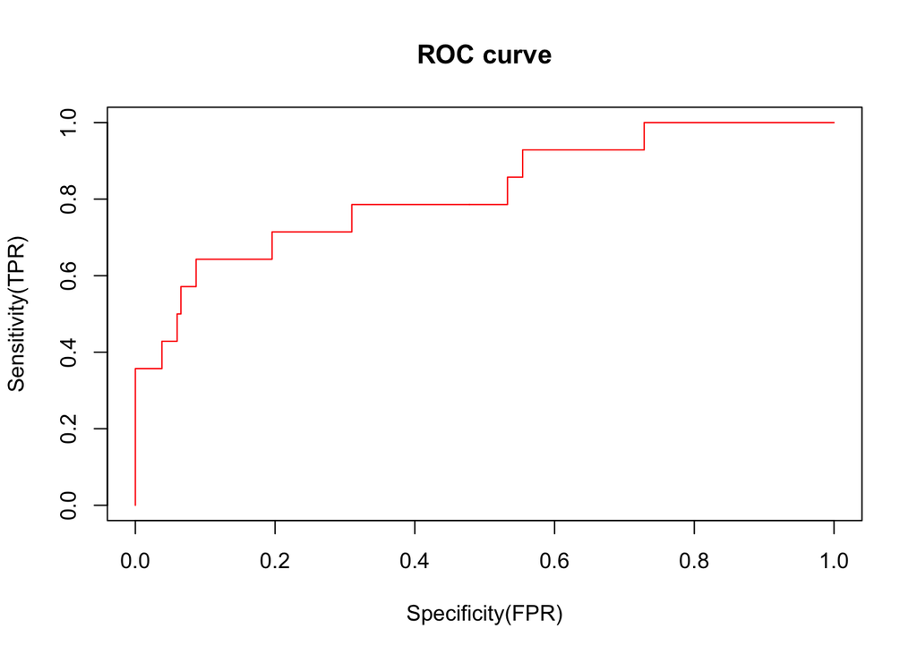

```r
### ROC Plot
pred_IPOVariable <- ROCR::prediction(Logis_pred_IPO, labels = TestData_IPO$IPOFail)
perf_IPOVariable <- performance(pred_IPOVariable, measure = "tpr", x.measure = "fpr")
#計算AUC
auc_IPO <- performance(pred_IPOVariable, "auc")

#畫圖
plot(perf_IPOVariable, col = "red", main = "ROC curve", xlab = "Specificity(FPR)", ylab = "Sensitivity(TPR)")
```

```r
#實際AUC值
auc_IPO@y.values[[1]] %>%
  kable(., caption = "AUC", align = "l") %>%
  kable_styling(full_width = TRUE)
```

AUC

| x |
| --- |
| 0.816382 |

```r
# library(InformationValue)
# # Cutoff
# Logis_optCutOff <- optimalCutoff(actuals = TestData_IPO$IPOFail ,
#                        predictedScores = Logis_pred_IPO)
#
# Logis_newpred_IPO_1 <- ifelse(Logis_pred_IPO > Logis_optCutOff , 1 , 0)
# Logis_table_new <- table(Logis_newpred_IPO_1 , real = TestData_IPO$IPOFail)
# Logis_table_new
# prop.table(Logis_table_new)
# DT_accuracy <- sum(diag(Logis_table_new) / sum(Logis_table_new))


# #---------- Precision、Recall、F1 ----------
# # Precision =
# caret::precision(data = Logis_table_IPO,  relevant = "1")
# # Recall =
# caret::recall(Logis_table_IPO , relevant = "1")
# # F1 =
# caret::F_meas(Logis_table_IPO , relevant = "1")
```

- 丟入所有的變數，可以發現ROC(AUC)值提高。
- IPO變數中，多了NegativeNetIncome1 顯著。
1. 不動產、廠房及設備對權益比率_ToMarket 越高，IPO失敗率降低(公式：固定資產/股東權益，越高代表公司的固定資產購入大於股東權益，表示公司不夠穩健。)。
2. 流動比率_ToMarket 越高，IPO失敗率降低。
3. ROA(C)稅前息前折舊前_ToMarket 越高，IPO失敗率提高。
4. 貝里比率_ToMarket 越高，IPO失敗率提高(公式：營業毛利 /營業費用，值越大，代表入不敷出)。
5. Mean_AmihudRatio 越高，代表股票在興櫃期間流動性越差，IPO失敗率提高。
6. NegativeNetIncome1 IPO前有負的NI，IPO失敗率提高。

```r
## Training and Test For All Variables
TrainingData_All <- GetTrainingAndTestingData(Data_AllVariable_Nor, 0.7, 1)
TestData_All <- GetTrainingAndTestingData(Data_AllVariable_Nor, 0.7, 0)

## Use Training data to build logistic model, contain All variables
Model_Logistic_All <- glm(IPOFail ~ .,
                          data = TrainingData_All %>% .[, -c(1)],
                          family = binomial(link = logit))

# summary(Model_Logistic_All)

Stepwise_Logistic_All <- step(Model_Logistic_All,
                              direction = c("both"),
                              trace = 0)

summary(Stepwise_Logistic_All)
```

```
##
## Call:
## glm(formula = IPOFail ~ `不動產、廠房及設備對權益比率_ToMarket` +
##     流動比率_ToMarket + `ROA(C)稅前息前折舊前_ToMarket` +
##     貝里比率_ToMarket + 平均中籤率 + ROTC_Time + FirmAgeBeforeIPO +
##     HoldingDiff + `機構持股(比率)` + Mean_AmihudRatio +
##     NegativeNetIncome + Big4Natl, family = binomial(link = logit),
##     data = TrainingData_All %>% .[, -c(1)])
##
## Deviance Residuals:
##     Min       1Q   Median       3Q      Max
## -1.6219  -0.3822  -0.2233  -0.1412   2.7088
##
## Coefficients:
##                                         Estimate Std. Error z value
## (Intercept)                              -1.0328     0.3595  -2.873
## `不動產、廠房及設備對權益比率_ToMarket`  -1.8877     0.7624  -2.476
## 流動比率_ToMarket                        -0.9803     0.3690  -2.656
## `ROA(C)稅前息前折舊前_ToMarket`           0.2918     0.1687   1.730
## 貝里比率_ToMarket                         0.2565     0.1305   1.965
## 平均中籤率                                0.6524     0.1729   3.773
## ROTC_Time                                 0.4933     0.1815   2.719
## FirmAgeBeforeIPO                         -0.5424     0.2507  -2.164
## HoldingDiff                               1.0826     0.4397   2.462
## `機構持股(比率)`                          0.3794     0.2006   1.892
## Mean_AmihudRatio                          0.3006     0.1507   1.994
## NegativeNetIncome1                        2.4467     0.9949   2.459
## Big4Natl1                                -2.7241     0.4798  -5.678
##                                         Pr(>|z|)
## (Intercept)                             0.004071 **
## `不動產、廠房及設備對權益比率_ToMarket` 0.013289 *
## 流動比率_ToMarket                       0.007901 **
## `ROA(C)稅前息前折舊前_ToMarket`         0.083592 .
## 貝里比率_ToMarket                       0.049374 *
## 平均中籤率                              0.000161 ***
## ROTC_Time                               0.006552 **
## FirmAgeBeforeIPO                        0.030496 *
## HoldingDiff                             0.013803 *
## `機構持股(比率)`                        0.058517 .
## Mean_AmihudRatio                        0.046106 *
## NegativeNetIncome1                      0.013924 *
## Big4Natl1                               1.37e-08 ***
## ---
## Signif. codes:  0 '***' 0.001 '**' 0.01 '*' 0.05 '.' 0.1 ' ' 1
##
## (Dispersion parameter for binomial family taken to be 1)
##
##     Null deviance: 281.29  on 460  degrees of freedom
## Residual deviance: 202.67  on 448  degrees of freedom
## AIC: 228.67
##
## Number of Fisher Scoring iterations: 7
```

```r
# 共線性檢測
car::vif(Stepwise_Logistic_All) %>%
  data.frame() %>%
  kable(., caption = "VIF Test", align = "l") %>%
  kable_styling(full_width = TRUE)
```

VIF Test

|  | . |
| --- | --- |
| `不動產、廠房及設備對權益比率_ToMarket` | 1.343569 |
| 流動比率_ToMarket | 1.462069 |
| `ROA(C)稅前息前折舊前_ToMarket` | 1.575916 |
| 貝里比率_ToMarket | 1.206120 |
| 平均中籤率 | 1.569086 |
| ROTC_Time | 1.421704 |
| FirmAgeBeforeIPO | 1.290423 |
| HoldingDiff | 1.205167 |
| `機構持股(比率)` | 1.228519 |
| Mean_AmihudRatio | 1.325393 |
| NegativeNetIncome | 1.591860 |
| Big4Natl | 1.417129 |

```r
PseudoR2(Stepwise_Logistic_All, which = "Nagelkerke") %>%
  data.frame() %>%
  kable(., caption = "R Squared", align = "l") %>%
  kable_styling(full_width = TRUE)
```

R Squared

|  | . |
| --- | --- |
| Nagelkerke | 0.3433087 |

```r
Logis_pred_All <- predict(Stepwise_Logistic_All ,
                      newdata = TestData_All ,
                      type = 'response')

Logis_newpred_All <- ifelse(Logis_pred_All > 0.5, 1, 0)
Logis_table_All <- table(Logis_newpred_All , real = TestData_All$IPOFail)

Logis_table_All %>%
  kable(., caption = "混淆矩陣：欄位為真實情況(閥值為 50%)", align = "l") %>%
  kable_styling(full_width = TRUE)
```

混淆矩陣：欄位為真實情況(閥值為 50%)

|  | 0 | 1 |
| --- | --- | --- |
| 0 | 182 | 9 |
| 1 | 2 | 5 |

```r
ifelse(Logis_pred_All > 0.1, 1, 0) %>%
  table(. , real = TestData_All$IPOFail) %>%
  kable(., caption = "混淆矩陣：欄位為真實情況(閥值為 10%)", align = "l") %>%
  kable_styling(full_width = TRUE)
```

混淆矩陣：欄位為真實情況(閥值為 10%)

|  | 0 | 1 |
| --- | --- | --- |
| 0 | 151 | 3 |
| 1 | 33 | 11 |

```r
# prop.table(Logis_table_All)
DT_accuracy <- sum(diag(Logis_table_All) / sum(Logis_table_All))

DT_accuracy %>%
  kable(., caption = "準確率", align = "l") %>%
  kable_styling(full_width = TRUE)
```

準確率

| x |
| --- |
| 0.9444444 |

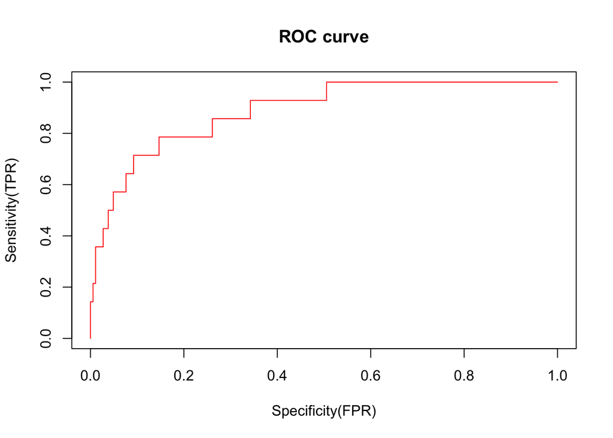

```r
# ## 利用 Information Value 找出 OptimalCutoff Point
# library(InformationValue)
# # Cutoff
# Logis_optCutOff <- optimalCutoff(actuals = TestData_All$IPOFail ,
#                        predictedScores = Logis_pred_All)
#
# Logis_newpred_All_1 <- ifelse(Logis_pred_All > Logis_optCutOff , 1 , 0)
# Logis_table_new <- table(Logis_newpred_All_1 , real = TestData_All$IPOFail)
# Logis_table_new
# prop.table(Logis_table_new)
# DT_accuracy <- sum(diag(Logis_table_new) / sum(Logis_table_new))
# DT_accuracy

### ROC Plot
pred_AllVariable <- ROCR::prediction(Logis_pred_All, labels = TestData_All$IPOFail)
perf_AllVariable <- performance(pred_AllVariable, measure = "tpr", x.measure = "fpr")
#計算AUC
auc <- performance(pred_AllVariable, "auc")

#畫圖
plot(perf_AllVariable, col = "red", main = "ROC curve", xlab = "Specificity(FPR)", ylab = "Sensitivity(TPR)")
```

```r
#實際AUC值
auc@y.values[[1]] %>%
  kable(., caption = "AUC", align = "l") %>%
  kable_styling(full_width = TRUE)
```

AUC

| x |
| --- |
| 0.8881988 |

```r
# #---------- Precision、Recall、F1 ----------
# # Precision =
# caret::precision(data = Logis_table_new,  relevant = "1")
# # Recall =
# caret::recall(Logis_table_new , relevant = "1")
# # F1 =
# caret::F_meas(Logis_table_new , relevant = "1")
```